# Kinship Dynamics: Concept, Modelling, and Applications

National University of Singapore, Singapore, February 5, 2025

Instructors: Diego Alburez-Gutierrez & Sha Jiang

Updated: 2025-01-24

## Introduction

### Preparation

Please make sure to complete the following preparatory steps before the training workshop:

1. If you haven’t already, install R and RStudio. This is a useful tutorial: https://rstudio-education.github.io/hopr/starting.html
2. Make sure the following packages area installed in R:

```r
install.packages("tidyverse")
install.packages("devtools")
devtools::install_github("IvanWilli/DemoKin")
```

### Course description:

Kinship is a fundamental property of human populations and a key form of social structure. Demographers have long been interested in the interplay between demographic change and family configuration. This has led to the development of sophisticated methodological and conceptual approaches for the study of kinship, some of which are reviewed in this course.

Some useful things to know:

- The course’s slides are available here: https://github.com/alburezg/kinship_workshop_NUS/tree/master/slides
- Find this website’s source code on GitHub: https://github.com/alburezg/kinship_workshop_NUS

## Part 1: Kinship

#### 1. Installation

#### Load other packages that will be useful:

```r
library(dplyr)
library(tidyr)
library(ggplot2)
```

### Input demographic data

```r
#Load data
rates_female <- read.csv("data/col_female.csv", stringsAsFactors = F) #female rates
pop_female <- read.csv("data/col_popfemale.csv", stringsAsFactors = F) #female population (N)
# For men
rates_male <- read.csv("data/col_male.csv", stringsAsFactors = F) # male rates
pop_male <- read.csv("data/col_popmale.csv", stringsAsFactors = F) # male population (N)
```

Let’s see what data we will be using. The first object is `rates_female`, a long-format data frame with year- and age-specific fertility rates (‘fx’) and survival probabilities from a life table (‘px’).

```r
head(rates_female)
```

```
##   Location    Sex year age        px fx
## 1 Colombia Female 1950   0 0.8811348  0
## 2 Colombia Female 1950   1 0.9689702  0
## 3 Colombia Female 1950   2 0.9788570  0
## 4 Colombia Female 1950   3 0.9853639  0
## 5 Colombia Female 1950   4 0.9896377  0
## 6 Colombia Female 1950   5 0.9925520  0
```

Let us visualise some of our demographic data. We start with the probability of dying between ages $x$ and $x+1$,$q_x$ in a life table:

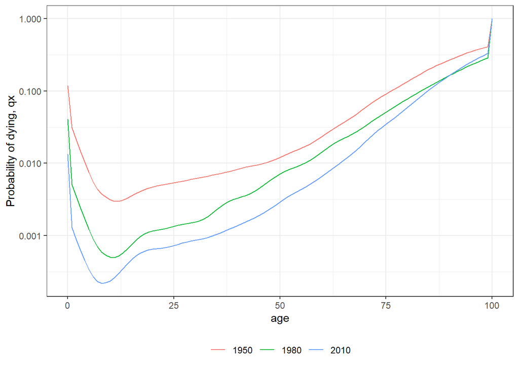

```r
rates_female %>%
    filter(year %in% seq(1950, 2020, 30)) %>%
    mutate(qx = 1-px) %>%
    ggplot() +
    geom_line(aes(x = age, y = qx, col = as.character(year))) +
    scale_y_log10() +
    labs(y = "Probability of dying, qx", col = NULL) +
    theme_bw() +
    theme(legend.position = "bottom")
```

Next, we have age-specific fertility rates for multiple years:

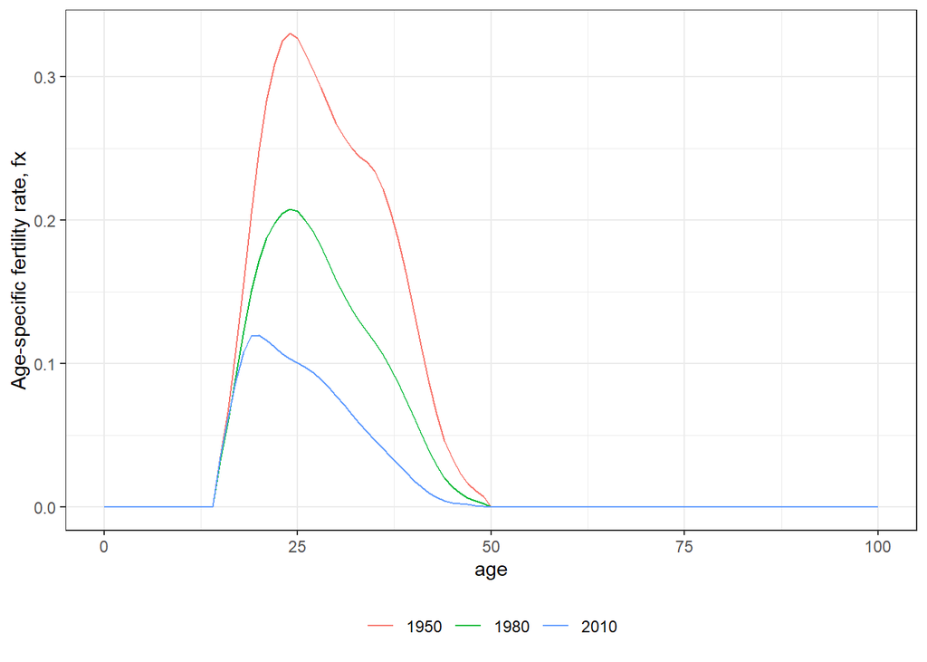

```r
rates_female %>%
  filter(year %in% seq(1950, 2020, 30)) %>%
  ggplot() +
  geom_line(aes(x = age, y = fx, col = as.character(year))) +
  labs(y = "Age-specific fertility rate, fx", col = NULL) +
  theme_bw() +
  theme(legend.position = "bottom")
```

Finally, we have the population counts:

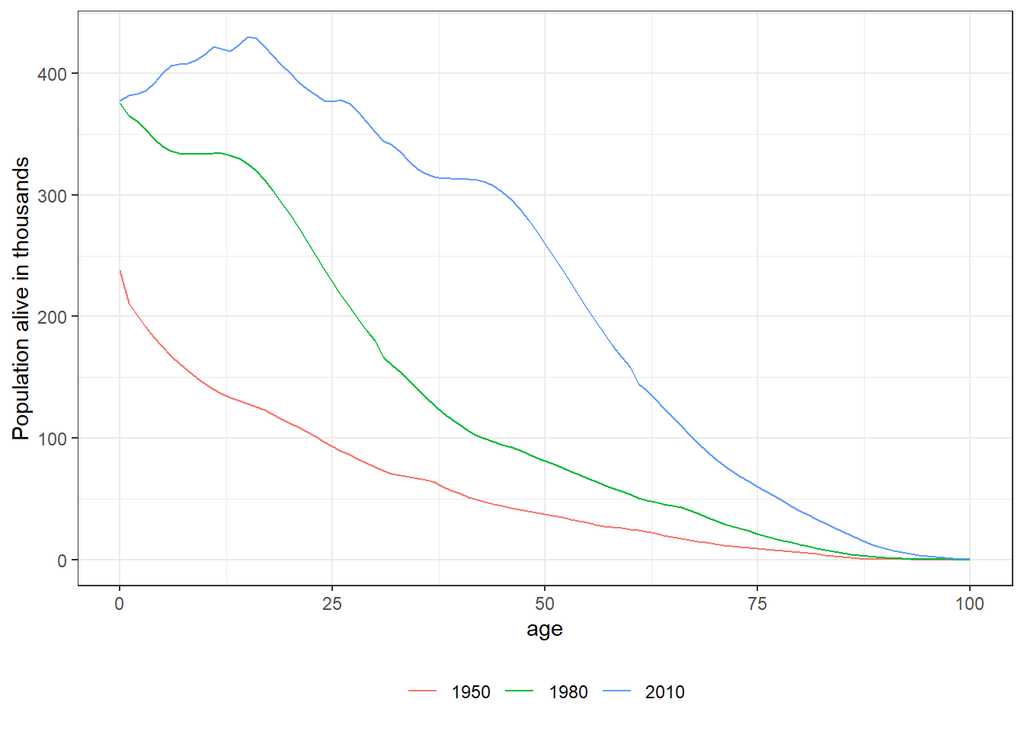

```r
pop_female %>%
  mutate(age = 0:100) %>%
  pivot_longer(-age, names_to = "year", values_to = "pop") %>%
  mutate(year = gsub("X", "", year)) %>%
  filter(year %in% seq(1950, 2020, 30)) %>%
  ggplot() +
  geom_line(aes(x = age, y = pop, col = as.character(year))) +
  labs(y = "Population alive in thousands", col = NULL) +
  theme_bw() +
  theme(legend.position = "bottom")
```

### 1. The DemoKin package

Load the package into R. If you haven’t done so already, install DemoKin from GitHub:

```r
# Install the development version from GitHub

#install.packages("devtools")
#devtools::install_github("IvanWilli/DemoKin")

library(DemoKin)
```

#### 1.1. The function `kin()`

`DemoKin` can be used to compute the number and age distribution of Focal’s relatives under a range of assumptions, including living and deceased kin. The function `DemoKin::kin()` currently does most of the heavy lifting in terms of implementing matrix kinship models.

## Part 2: Projections